# Pandas Series

### FIlling missing Data with Computed data

the dataframe method `df.fillna()` will replace the `NaN` values with your specified function

```python
df2.A.fillna(df2.A.median(), inplace=True)
```

```python
df2
```

|  | A | B | C |
| --- | --- | --- | --- |
| 0 | 1.0 | 23.0 | 89 |
| 1 | 2.0 | 13.0 | 34 |
| 2 | 3.0 | NaN | 34 |
| 3 | 4.0 | NaN | 32 |
| 4 | 2.5 | NaN | 12 |

```python
df2.B.fillna(df2.B.mean(), inplace=True)
```

```python
df2
```

|  | A | B | C |
| --- | --- | --- | --- |
| 0 | 1.0 | 23.0 | 89 |
| 1 | 2.0 | 13.0 | 34 |
| 2 | 3.0 | 18.0 | 34 |
| 3 | 4.0 | 18.0 | 32 |
| 4 | 2.5 | 18.0 | 12 |

[figure not shown]

```python
Image("../src/photos/brain_in_coffee.png")
```

### Exercise

Using the Titanic Data set to practice Transformations

```python
titanic = pd.read_csv("../data/titanic.csv")
```

```python
titanic.head()
```

|  | PassengerId | Survived | Pclass | Name | Sex | Age | SibSp | Parch | Ticket | Fare | Cabin | Embarked |
| --- | --- | --- | --- | --- | --- | --- | --- | --- | --- | --- | --- | --- |
| 0 | 1 | 0 | 3 | Braund, Mr. Owen Harris | male | 22.0 | 1 | 0 | A/5 21171 | 7.2500 | NaN | S |
| 1 | 2 | 1 | 1 | Cumings, Mrs. John Bradley (Florence Briggs Th... | female | 38.0 | 1 | 0 | PC 17599 | 71.2833 | C85 | C |
| 2 | 3 | 1 | 3 | Heikkinen, Miss. Laina | female | 26.0 | 0 | 0 | STON/O2. 3101282 | 7.9250 | NaN | S |
| 3 | 4 | 1 | 1 | Futrelle, Mrs. Jacques Heath (Lily May Peel) | female | 35.0 | 1 | 0 | 113803 | 53.1000 | C123 | S |
| 4 | 5 | 0 | 3 | Allen, Mr. William Henry | male | 35.0 | 0 | 0 | 373450 | 8.0500 | NaN | S |

```python
titanic.tail()
```

|  | PassengerId | Survived | Pclass | Name | Sex | Age | SibSp | Parch | Ticket | Fare | Cabin | Embarked |
| --- | --- | --- | --- | --- | --- | --- | --- | --- | --- | --- | --- | --- |
| 886 | 887 | 0 | 2 | Montvila, Rev. Juozas | male | 27.0 | 0 | 0 | 211536 | 13.00 | NaN | S |
| 887 | 888 | 1 | 1 | Graham, Miss. Margaret Edith | female | 19.0 | 0 | 0 | 112053 | 30.00 | B42 | S |
| 888 | 889 | 0 | 3 | Johnston, Miss. Catherine Helen "Carrie" | female | NaN | 1 | 2 | W./C. 6607 | 23.45 | NaN | S |
| 889 | 890 | 1 | 1 | Behr, Mr. Karl Howell | male | 26.0 | 0 | 0 | 111369 | 30.00 | C148 | C |
| 890 | 891 | 0 | 3 | Dooley, Mr. Patrick | male | 32.0 | 0 | 0 | 370376 | 7.75 | NaN | Q |

```python
titanic.shape
```

```
(891, 12)
```

```python
titanic.describe()
```

|  | PassengerId | Survived | Pclass | Age | SibSp | Parch | Fare |
| --- | --- | --- | --- | --- | --- | --- | --- |
| count | 891.000000 | 891.000000 | 891.000000 | 714.000000 | 891.000000 | 891.000000 | 891.000000 |
| mean | 446.000000 | 0.383838 | 2.308642 | 29.699118 | 0.523008 | 0.381594 | 32.204208 |
| std | 257.353842 | 0.486592 | 0.836071 | 14.526497 | 1.102743 | 0.806057 | 49.693429 |
| min | 1.000000 | 0.000000 | 1.000000 | 0.420000 | 0.000000 | 0.000000 | 0.000000 |
| 25% | 223.500000 | 0.000000 | 2.000000 | 20.125000 | 0.000000 | 0.000000 | 7.910400 |
| 50% | 446.000000 | 0.000000 | 3.000000 | 28.000000 | 0.000000 | 0.000000 | 14.454200 |
| 75% | 668.500000 | 1.000000 | 3.000000 | 38.000000 | 1.000000 | 0.000000 | 31.000000 |
| max | 891.000000 | 1.000000 | 3.000000 | 80.000000 | 8.000000 | 6.000000 | 512.329200 |

```python
titanic.info()
```

```
<class 'pandas.core.frame.DataFrame'>
RangeIndex: 891 entries, 0 to 890
Data columns (total 12 columns):
PassengerId    891 non-null int64
Survived       891 non-null int64
Pclass         891 non-null int64
Name           891 non-null object
Sex            891 non-null object
Age            714 non-null float64
SibSp          891 non-null int64
Parch          891 non-null int64
Ticket         891 non-null object
Fare           891 non-null float64
Cabin          204 non-null object
Embarked       889 non-null object
dtypes: float64(2), int64(5), object(5)
memory usage: 83.6+ KB
```

```python
titanic.isnull().sum()
```

```
PassengerId      0
Survived         0
Pclass           0
Name             0
Sex              0
Age            177
SibSp            0
Parch            0
Ticket           0
Fare             0
Cabin          687
Embarked         2
dtype: int64
```

```python
titanic.Survived.value_counts()
```

```
0    549
1    342
Name: Survived, dtype: int64
```

```python
titanic.Pclass.value_counts()
```

```
3    491
1    216
2    184
Name: Pclass, dtype: int64
```

```python
titanic.Sex.value_counts()
```

```
male      577
female    314
Name: Sex, dtype: int64
```

```python
titanic.Embarked.value_counts()
```

```
S    644
C    168
Q     77
Name: Embarked, dtype: int64
```

```python
titanic.Survived.fillna(value=0, inplace=True)
```

```python
titanic.Age.fillna(titanic.Age.median(), inplace=True)
```

```python
titanic.Embarked.fillna(value = "S", inplace=True)
```

```python
titanic.Age.mean()
```

```
29.36158249158249
```

```python
titanic_grouped = titanic.groupby("Survived")
```

```python
titanic_grouped.Age.mean()
```

```
Survived
0    30.028233
1    28.291433
Name: Age, dtype: float64
```

```python
titanic_grouped[["Age", "Fare"]].mean()
```

| Survived | Age | Fare |
| --- | --- | --- |
| 0 | 30.028233 | 22.117887 |
| 1 | 28.291433 | 48.395408 |

```python
titanic_grouped_1 = titanic.groupby(["Survived", "Pclass"])
```

```python
titanic_grouped_1.PassengerId.count()
```

```
Survived  Pclass
0         1          80
          2          97
          3         372
1         1         136
          2          87
          3         119
Name: PassengerId, dtype: int64
```

```python
titanic.to_csv("titanic_new_1.csv", index = False)
```

# Importing Excel Files

```python
excel_file = pd.read_excel("../data/battledeath.xlsx", sheetname="2002")
```

```python
excel_file.head()
```

|  | War, age-adjusted mortality due to | 2002 |
| --- | --- | --- |
| 0 | Afghanistan | 36.083990 |
| 1 | Albania | 0.128908 |
| 2 | Algeria | 18.314120 |
| 3 | Andorra | 0.000000 |
| 4 | Angola | 18.964560 |

# Importing SQL files

```python
from sqlalchemy import create_engine
```

```python
engine = create_engine('sqlite:///Chinook.sqlite')
```

```python
table_names = engine.table_names()
```

```python
print(table_names)
```

```
[]
```

```python
con = engine.connect()
```

```python
rs = con.execute("SELECT * FROM Album")
```

```python
df = pd.DataFrame(rs.fetchall())
```

```python
df.columns = rs.keys()
```

```python
df.head()
```

[output not shown]

```python
con.close()
```

```python
df.shape
```

```python
df = pd.read_sql_query("SELECT * FROM Album", engine)
```

```python
df.head()
```

```python
df = pd.read_sql_query(
    "SELECT * FROM Employee WHERE EmployeeId >= 6 ORDER BY BirthDate",
    engine)
```

```python
df.head()
```

# Hopefully Coffee

Probably not

[figure not shown]

```python
Image('../src/photos/take_a_little_coffee_break.png')
```

### Working with String

#### Create a Pandas Series

```python
s = pd.Series(['A', 'B', 'C', 'Aaba', 'Baca', np.nan, 'CABA', 'dog', 'cat', "My name is Ravi"])
```

#### Convert the series into upper case letters

```python
s.str.upper()
```

#### Convert the series into lower case letters

```python
s.str.lower()
```

#### Capitalize the series

```python
s.str.capitalize()
```

#### Find the length of each item in the series

```python
s.str.len()
```

### Create another series with whitespaces

```python
test = pd.Series([' jack', 'jill ', ' jesse ', 'frank', "Bob Martin"])
```

```python
test
```

#### Remove all the whitespaces

```python
test.str.strip()
```

#### Remove whitespace from the left

```python
test.str.lstrip()
```

#### Remove whitespace from the right

```python
test.str.rstrip()
```

### Correct the column names

#### Create a dataframe

```python
df = pd.DataFrame(np.random.randn(3, 2), columns=[' Column A ', ' Column B '], index=range(3))
```

```python
df
```

```python
df.columns = df.columns.str.strip().str.lower().str.replace(' ', '_')
```

```python
df
```

### Split and Replace

```python
s2 = pd.Series(['a_b_c', 'c_d_e', np.nan, 'f_g_h'])
```

```python
s2
```

```python
s2.str.split('_')
```

```python
s2.str.split('_').str[0]
```

```python
s2.str.split('_').str.get(0)
```

### Create a Series of 5 email address and split the username and domain address seperately

```python
email_list = ['random@tamu.edu', 'aPerson@gmail.com', 'jessica@yahoo.co.in', 'sammy@hotmail.com', 'jenny@wagner.edu']
email = pd.Series(email_list)
email
```

```python
email.str.split('@')
```

```python
email.str.split('@').str[1]
```

```python
email.str.split('@', expand=True)
```

```python
s2
```

```python
s2.str.split('_', expand=True)
```

```python
s2.str.split('_', expand=True, n = 1)
```

### Right Split

```python
s2.str.rsplit('_', expand=True, n = 1)
```

[figure not shown]

```python
Image('../src/photos/question_kitteh.png')
```

### Replacing Data Inside A DatFrame

Values of the DataFrame are replaced with other values dynamically. This differs from updating with `.loc` or `.iloc`, which require you to specify a location to update with some value.

```python
s3 = pd.Series(['A', 'B', 'C', 'Aaba', 'Baca','', np.nan, 'CABA', 'dog', 'cat'])
```

```python
s3
```

```python
s3.str.replace('a', 'apple')
```

```python
s3.str.replace('a', 'oranges', case=False)
```

```python
dollars = pd.Series(['12', '-$10', '$10,000'])
```

```python
dollars.str.replace('$', '')
```

### Matching a containing pattern

```python
s4 = pd.Series(['A', 'B', 'C', 'Aaba', 'Baca', np.nan, 'CABA', 'dog', 'cat'])
s4
```

```python
s4.str.contains('A')
```

```python
s4.str.contains('A', case=False)
```

### Concatenating String

```python
s = pd.Series(['a','b',np.nan,'c'])
s
```

```python
s.str.cat(sep=' ')
```

```python
s.str.cat(sep=' ', na_rep='?')
```

```python
s1 = pd.Series(['a','b','c'])
s2 = pd.Series(['d', 'e', 'f'])
```

```python
s1.str.cat(others=s2, sep=',')
```

```python
s1 = pd.Series([['a', 'b'], ['c', 'd'], ['e','f']])
s1
```

```python
s1.str.join(',')
```

```python
s2.str.repeat(3)
```

### Group-By

- Group DataFrame or Series using a mapper or by a Series of columns.

A `DataFrame.groupby` operation involves some combination of splitting the object, applying a function, and combining the results.

This can be used to group large amounts of data and compute operations on these groups.

```python
df = pd.DataFrame({'A' : ['foo', 'bar', 'foo', 'bar',
                          'foo', 'bar', 'foo', 'foo'],
                   'B' : ['one', 'one', 'two', 'three',
                          'two', 'two', 'one', 'three'],
                   'C' : np.random.randn(8),
                   'D' : np.random.randn(8)})
```

```python
df
```

```python
grouped = df.groupby('A')
```

```python
grouped
```

```python
grouped.sum()
```

```python
#default for sort is True
grouped = df.groupby('A', sort=False)
```

```python
grouped.sum()
```

```python
#Print everything for a group
grouped.get_group('foo')
```

```python
grouped.groups
```

```python
len(grouped)
```

```python
grouped = df.groupby('A')

for name, group in grouped:
    print(name)
    print(group)
```

[figure not shown]

```python
Image('../src/photos/keep_calm_ask.png')
```

## `pd.DataFrame.aggregate()`

Aggregate using one or more operations over the specified axis

If a function, must either work when passed a DataFrame or when passed to `DataFrame.apply`

- aggregation operations are always performed over an axis
  - index (default) or the column axis.
  - This behavior is different from `numpy` aggregation functions (`mean`, `median`, `prod`, `sum`, `std`,`var`), where the default is to compute the aggregation of the flattened array

```python
grouped = df.groupby('A')
```

```python
grouped.aggregate(np.sum)
```

```python
grouped = df.groupby(['A', 'B'])
```

```python
grouped.aggregate(np.sum)
```

```python
grouped = df.groupby(['A', 'B'], as_index=False)
grouped.aggregate(np.sum)
```

```python
grouped = df.groupby('A', as_index=False)
grouped.aggregate(np.sum)
```

```python
df.groupby(['A', 'B']).sum().reset_index()
```

```python
grouped = df.groupby('A')
grouped.size()
```

```python
grouped.describe()
```

```python
grouped = df.groupby('A')
```

```python
grouped['C'].agg([np.sum, np.mean, np.std])
```

```python
# lambda's are anonymous functions defined inline
grouped.agg({'C' : np.sum,
             'D' : lambda x: np.std(x, ddof=1)})
```

```python
grouped.sum()
```

### Filtering using a lambda

Lambda expressions (sometimes called lambda forms) are used to create anonymous functions. The expression `lambda parameters: expression` yields a function object.

```python
sf = pd.Series([1, 1, 2, 3, 3, 3, 4, 5], index=[0, 1, 2, 3, 4, 4, 5, 5])
```

```python
sf
```

```python
sf.groupby(sf).filter(lambda x: x.sum() > 2)
```

# Timestamp - most basic type of date data

```python
pd.Timestamp('2012-05-01')
```

```python
pd.Timestamp(2012, 5, 1)
```

```python
ts = pd.Series(['Jul 31, 2009', '2010-01-10', None])
```

```python
ts
```

```python
pd.to_datetime(ts)
```

```python
ts = pd.Series(['2005/11/23', '2010.12.31'])
```

```python
pd.to_datetime(ts)
```

## Formating with arguments

```python
pd.to_datetime('2010/11/12', format='%Y/%m/%d')
```

```python
pd.to_datetime('12-11-2010 00:00', format='%d-%m-%Y %H:%M')
```

### Handling Errors

```python
pd.to_datetime(['2009/07/31', 'asd'], errors='ignore')
```

```python
pd.to_datetime(['2009/07/31', 'asd'], errors='coerce')
```

### Unix TimeStamps

```python
pd.to_datetime([1349720105, 1349806505, 1349892905,1349979305, 1350065705], unit='s')
```

```python
 pd.to_datetime([1349720105100, 1349720105200, 1349720105300,1349720105400, 1349720105500 ], unit='ms')
```

## Creating Timestamps

```python
stamps = pd.date_range('2012-10-08 18:15:05', periods=4, freq='D')
```

```python
stamps
```

```python
start = dt.date(2011, 1, 1)
```

```python
end = dt.date(2012, 1, 1)
```

```python
index = pd.date_range(start, end)
```

```python
index
```

## Slicing By Timestamps

```python
ts['10/31/2011':'12/31/2011']
```

```python
dft = pd.DataFrame(np.random.randn(100000,1),columns=['A'],index=pd.date_range('20130101',periods=100000,freq='T'))
```

```python
dft[:10].head()
```

```python
dft.loc['2013', :].head()
```

```python
dft.loc['2013-1':'2013-2'].head()
```

[figure not shown]

```python
Image('../src/photos/nerd_kitteh.png')
```

## Time Series Analysis

```python
rng = pd.date_range('1/1/2012', periods=1000, freq='S')
```

```python
ts = pd.Series(np.random.randint(0, 500, len(rng)), index=rng)
```

```python
ts.head()
```

### Using the Resample Function for timeseries data

Convenience method for frequency conversion and resampling of time series. Object must have a datetime-like index (`DatetimeIndex`, `PeriodIndex`, or `TimedeltaIndex`), or pass datetime-like values to the `on` or `level` keyword.

```python
ts.resample('5Min').sum()
```

```python
ts.resample('5Min').mean()
```

```python
ts.resample('5Min').max()
```

```python
ts.resample('5Min').ohlc()
```

```python
rng2 = pd.date_range('1/1/2012', end='3/31/2012', freq='D')
```

```python
ts2 = pd.Series(range(len(rng2)), index=rng2)
```

```python
ts2.head()
```

```python
ts2.resample('M').max()
```

```python
ts2.resample('M').mean()
```

### Combining DataFrames with `concat` and `join`

`concat(objs, axis=0, join='outer', join_axes=None,ignore_index=False, keys=None, levels=None, sort=None, copy=True)`

Concatenate pandas objects along a particular axis with optional set logic along the other axes.

Can also add a layer of hierarchical indexing on the concatenation axis, which may be useful if the labels are the same (or overlapping) on the passed axis number.

```python
df1 = pd.DataFrame({'A': ['A0', 'A1', 'A2', 'A3'],
                    'B': ['B0', 'B1', 'B2', 'B3'],
                    'C': ['C0', 'C1', 'C2', 'C3'],
                    'D': ['D0', 'D1', 'D2', 'D3']},
                   index=[0, 1, 2, 3])


df2 = pd.DataFrame({'A': ['A4', 'A5', 'A6', 'A7'],
                    'B': ['B4', 'B5', 'B6', 'B7'],
                    'C': ['C4', 'C5', 'C6', 'C7'],
                    'D': ['D4', 'D5', 'D6', 'D7']},
                   index=[4, 5, 6, 7])

df3 = pd.DataFrame({'A': ['A8', 'A9', 'A10', 'A11'],
                    'B': ['B8', 'B9', 'B10', 'B11'],
                    'C': ['C8', 'C9', 'C10', 'C11'],
                    'D': ['D8', 'D9', 'D10', 'D11']},
                   index=[8, 9, 10, 11])
```

```python
print(df1, df2,df3)
```

```python
frames = [df1, df2, df3]
```

```python
result = pd.concat(frames)
```

```python
result
```

```python
pd.concat(frames, axis=1)
```

```python
#     Add a hierarchical index at the outermost level of
#     the data with the ``keys`` option.
pd.concat(frames, keys=['x', 'y', 'z'])
```

```python
results= pd.concat(frames, keys=['x', 'y', 'z'])
```

```python
type(results)
```

```python
results.loc["x", :].loc[1:3, :]
```

```python
df4 = pd.DataFrame({'B': ['B2', 'B3', 'B6', 'B7'],
                    'D': ['D2', 'D3', 'D6', 'D7'],
                    'F': ['F2', 'F3', 'F6', 'F7']},
                   index=[2, 3, 6, 7])
```

```python
df1
```

```python
df4
```

```python
# /
pd.concat([df1, df4], axis=1)
```

## inner, outer, and axis joins

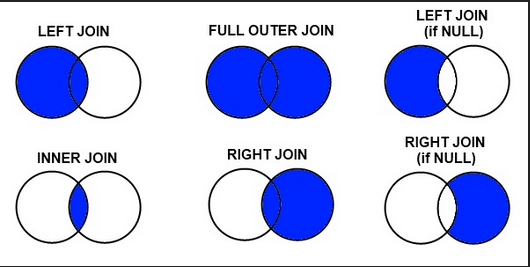

```python
Image('../src/photos/pandas_joins.png')
```

```python
#     Combine ``DataFrame`` objects with overlapping columns
#     and return only those that are shared by passing ``inner`` to
#     the ``join`` keyword argument.
pd.concat([df1, df4], axis=1, join='inner')
```

```python
#     join_axes : list of Index objects
#         Specific indexes to use for the other n - 1 axes instead of performing
#         inner/outer set logic
pd.concat([df1, df4], axis=1, join_axes=[df1.index])
```

```python
pd.concat([df1, df4], axis=1, join_axes=[df4.index])
```

```python
# Clear the existing index and reset it in the result
# by setting the ``ignore_index`` option to ``True``.
pd.concat([df1, df4], ignore_index=True)
```

```python
df1.append(df4)
```

### Appending rows to a DataFrame

```python
s2 = pd.Series(['X0', 'X1', 'X2', 'X3'], index=['A', 'B', 'C', 'D'])

results = df1.append(s2, ignore_index=True)
results
```

```python
dicts = [{'A': 1, 'B': 2, 'C': 3, 'X': 4},
         {'A': 5, 'B': 6, 'C': 7, 'Y': 8}]

result = df1.append(dicts, ignore_index=True)
result
```

### Database-style DataFrame joining/merging

```python
left = pd.DataFrame({'key': ['K0', 'K1', 'K2', 'K3'],
                     'A': ['A0', 'A1', 'A2', 'A3'],
                     'B': ['B0', 'B1', 'B2', 'B3']})

right = pd.DataFrame({'key': ['K0', 'K1', 'K2', 'K3'],
                      'C': ['C0', 'C1', 'C2', 'C3'],
                      'D': ['D0', 'D1', 'D2', 'D3']})
```

```python
left
```

```python
right
```

## Using the `merge` function

`merge(left, right, how='inner', on=None)`

Support for specifying index levels as the `on`, `left_on`, and `right_on` parameters

Merge DataFrame or named Series objects with a database-style join.

The join is done on columns or indexes. If joining columns on columns, the DataFrame indexes *will be ignored*. Otherwise if joining indexes on indexes or indexes on a column or columns, the index will be passed on.

```python
result = pd.merge(left, right, on='key')
```

```python
result
```

```python
left = pd.DataFrame({'key1': ['K0', 'K0', 'K1', 'K2'],
                     'key2': ['K0', 'K1', 'K0', 'K1'],
                     'A': ['A0', 'A1', 'A2', 'A3'],
                     'B': ['B0', 'B1', 'B2', 'B3']})

right = pd.DataFrame({'key1': ['K0', 'K1', 'K1', 'K2'],
                      'key2': ['K0', 'K0', 'K0', 'K0'],
                      'C': ['C0', 'C1', 'C2', 'C3'],
                      'D': ['D0', 'D1', 'D2', 'D3']})
```

```python
left
```

```python
right
```

```python
result = pd.merge(left, right, on=['key1', 'key2'])
```

```python
result
```

```python
result = pd.merge(left, right, how='left', on=['key1', 'key2'])
```

```python
result
```

```python
result = pd.merge(left, right, how='right', on=['key1', 'key2'])
```

```python
result
```

```python
result = pd.merge(left, right, how='outer', on=['key1', 'key2'])
result
```

```python
left = pd.DataFrame({'key1': ['K0', 'K0', 'K1', 'K2'],
                     'key2': ['K0', 'K1', 'K0', 'K1'],
                     'A': ['A0', 'A1', 'A2', 'A3'],
                     'B': ['B0', 'B1', 'B2', 'B3']})

right = pd.DataFrame({'key1_new': ['K0', 'K1', 'K1', 'K2'],
                      'key2_new': ['K0', 'K0', 'K0', 'K0'],
                      'C': ['C0', 'C1', 'C2', 'C3'],
                      'D': ['D0', 'D1', 'D2', 'D3']})
```

```python
left
```

```python
right
```

```python
result = pd.merge(left, right, how='left', left_on=['key1', 'key2'], right_on=["key1_new", "key2_new"])
```

```python
result
```

# If We Get to This

Pivot Tables or Why Never to Go Back to Excel

```python
import numpy as np
import pandas as pd
import matplotlib.pyplot as plt
import seaborn as sns
% matplotlib inline
```

```python
import pandas.util.testing as tm; tm.N = 3
def unpivot(frame):
    N, K = frame.shape
    data = {'value' : frame.values.ravel('F'),
            'variable' : np.asarray(frame.columns).repeat(N),
            'date' : np.tile(np.asarray(frame.index), K)}
    return pd.DataFrame(data, columns=['date', 'variable', 'value'])
df = unpivot(tm.makeTimeDataFrame())
```

```python
df
```

### To select any specific Category

```python
df.loc[df.variable == 'A', :]
```

### `Pandas.DataFrame.pivot_table`

Create a spreadsheet-style pivot table as a DataFrame. The levels in the pivot table will be stored in MultiIndex objects (hierarchical indexes) on the index and columns of the result DataFrame.

```python
df.pivot_table(index='date', columns='variable', values='value')
```

```python
df["value2"] = df["value"] ** 2
```

[output not shown]

```python
df
```

```python
df.pivot_table(index='date', columns='variable')
```

```python
pivioted = df.pivot_table(index='date', columns='variable')
pivioted.loc[ : , "value"]
```

[figure not shown]

```python
Image('../src/photos/question_kitteh.png')
```

### Aggregating Functions

```python
df.pivot_table(values='value', index='date', columns='variable', aggfunc=np.mean)
```

```python
df2 = df.pivot_table(values='value', index='date', columns='variable', aggfunc=np.median)
df2
```

```python
ages = pd.Series(np.array([10, 15, 13, 12, 23, 25, 28, 59, 60]))
```

```python
ages
```

### Binning Values with `pd.cut`

Use `cut` when you need to segment and sort data values into bins.

- function is also useful for going from a continuous variable to a categorical variable.
- For example, `cut` could convert ages to groups of age ranges.
- Supports binning into an equal number of bins, or a pre-specified array of bins.

```python
c = pd.cut(ages, bins=[0, 5, 10, 15, 20, 25, 30, 40, 50, 60])
c
```

```python
df
```

### Converting to indicator values with the `pd.get_dummies`

```python
pd.get_dummies(df['variable'])
```

```python
dummies = pd.get_dummies(df['variable'], prefix='variable')
dummies
```

```python
df.join(dummies)
```

```python
#  dummy_na : bool, default False
#         Add a column to indicate NaNs, if False NaNs are ignored.
dummies = pd.get_dummies(df['variable'], prefix='variable', drop_first=True, dummy_na=True)
dummies
```

[figure not shown]

```python
Image("../src/photos/take_a_little_coffee_break.png")
```

# Styling Tables

Fancy Pants Magic

```python
np.random.seed(24)
df = pd.DataFrame({'A': np.linspace(1, 10, 10)})
df = pd.concat([df, pd.DataFrame(np.random.randn(10, 4), columns=list('BCDE'))],
               axis=1)
df.iloc[0, 2] = np.nan
```

```python
df
```

```python
df.style
```

```python
df.style.highlight_null()
```

```python
def color_negative_red(val):
    color = 'red' if val < 0 else 'black'
    return 'color: %s' % color
```

```python
s = df.style.applymap(color_negative_red)
s
```

```python
def highlight_max(s):
    is_max = s == s.max()
    return ['background-color: yellow' if v else '' for v in is_max]
```

```python
df.style.apply(highlight_max)
```

```python
df.style.apply(highlight_max, subset=['B', 'C', 'D', 'E'])
```

```python
df.style.applymap(color_negative_red,
                  subset=pd.IndexSlice[2:5, ['B', 'D']])
```

```python
df.style.applymap(color_negative_red).apply(highlight_max)
```

```python
df.style.format("{:.2%}")
```

```python
df
```

```python
df.style.format({'B': "{:.2%}", 'D': '{:+.2f}'})
```

```python
df.style.set_properties(**{'background-color': 'black',
                           'color': 'lawngreen',
                           'border-color': 'pink'})
```

```python
df.style.bar(subset=['C'], color='#d65f5f')
```

```python
df.style.bar(subset=['B'], align='mid', color=['#d65f5f', '#5fba7d'])
```